# Pokémon Power Creep Analysis

Using Generalized Linear Models

Jan Tychtl

2025-12-13

# Introduction

## Main Research Question

**Is there Power Creep in the Pokémon Index?**

- Does generation significantly predict Pokémon strength (Attack)?
- How does attack change with generation after controlling for other factors?

## Methods Applied

Methods applied from SAN project reports analysis:

- OLS Regression, GLMs (Gaussian, Poisson, Gamma, Negative Binomial)
- LASSO/Ridge/ElasticNet regularization
- Backward Stepwise Selection
- ANOVA and Likelihood Ratio Tests
- Time-split Cross-Validation
- Spline functions and polynomial terms for non-linear effects
- Dispersion tests for overdispersion detection
- Comprehensive ablation study with caret cross-validation
- Diagnostic plots and model comparison (AIC/BIC)

*Inspired by: SAN_assignment_GLM_2.Rmd and glms.Rmd*

# 1. Setup and Data Loading

```r
library(tidyverse)
library(glmnet)       # LASSO, Ridge, ElasticNet
library(splines)      # Spline functions
library(car)          # ANOVA, VIF
library(MASS)         # stepAIC, robust regression, glm.nb (Negative Binomial)
library(broom)        # tidy model outputs
library(caret)        # Cross-validation with train()
library(ggplot2)      # Visualization
library(corrplot)     # Correlation plots
library(lmtest)       # Likelihood ratio tests
library(AER)          # dispersiontest() for overdispersion
library(rcompanion)   # compareGLM() for model comparison
library(gridExtra)    # Side-by-side plots
library(DescTools)    # Jonckheere-Terpstra test
library(moments)      # Skewness and kurtosis calculations
```

```r
# Set working directory and load data
setwd("/home/jenda/Desktop/SAN/pokedex_analysis")
pokemon <- read.csv("data/data_clean.csv")
pokemon_clean <- read.csv("data/data_no_outliers.csv")

cat("Full dataset:", nrow(pokemon), "Pokémon\n")
```

```
## Full dataset: 1024 Pokémon
```

```r
cat("Outlier-free dataset:", nrow(pokemon_clean), "Pokémon\n")
```

```
## Outlier-free dataset: 972 Pokémon
```

```r
cat("Removed as outliers:", nrow(pokemon) - nrow(pokemon_clean), "Pokémon\n")
```

```
## Removed as outliers: 52 Pokémon
```

**Note:** We load both the full dataset and the outlier-free version. A third dataset (`pokemon_normal`) containing only Normal-rarity Pokémon will be created after preprocessing to isolate the power creep analysis from legendary/mythical effects.

# 2. Data Exploration and Preprocessing

## 2.1 Data Overview

```r
cat("Dataset dimensions:", dim(pokemon), "\n")
```

```
## Dataset dimensions: 1024 41
```

```r
cat("Number of generations:", length(unique(pokemon$gen)), "\n")
```

```
## Number of generations: 9
```

```r
cat("Pokémon per generation:\n")
```

```
## Pokémon per generation:
```

```r
print(table(pokemon$gen))
```

```
##
##   1   2   3   4   5   6   7   8   9
## 151 100 135 107 156  72  88  95 120
```

```r
# Check structure
str(pokemon)
```

```
## 'data.frame':    1024 obs. of  41 variables:
##  $ gen               : num  1 1 1 1 1 1 1 1 1 1 ...
##  $ english_name      : chr  "Bulbasaur" "Ivysaur" "Venusaur" "Charmander" ...
##  $ percent_male      : num  88.1 88.1 88.1 88.1 88.1 ...
##  $ percent_female    : num  11.9 11.9 11.9 11.9 11.9 ...
##  $ height_m          : num  0.7 1 2 0.6 1.1 1.7 0.5 1 1.6 0.3 ...
##  $ weight_kg         : num  6.9 13 100 8.5 19 90.5 9 22.5 85.5 2.9 ...
##  $ capture_rate      : num  45 45 45 45 45 45 45 45 45 255 ...
##  $ base_egg_steps    : num  5120 5120 5120 5120 5120 5120 5120 5120 5120 3840 ...
##  $ hp                : num  45 60 80 39 58 78 44 59 79 45 ...
##  $ attack            : num  49 62 82 52 64 84 48 63 83 30 ...
##  $ defense           : num  49 63 83 43 58 78 65 80 100 35 ...
##  $ sp_attack         : num  65 80 100 60 80 109 50 65 85 20 ...
##  $ sp_defense        : num  65 80 100 50 65 85 64 80 105 20 ...
##  $ speed             : num  45 60 80 65 80 100 43 58 78 45 ...
```

[output cut: 27 more lines]

```r
summary(pokemon)
```

```
##       gen        english_name        percent_male    percent_female
##  Min.   :1.000   Length:1024        Min.   :  0.00   Min.   :  0.00
##  1st Qu.:3.000   Class :character   1st Qu.: 50.00   1st Qu.: 11.86
##  Median :5.000   Mode  :character   Median : 50.20   Median : 49.80
##  Mean   :4.738                      Mean   : 46.53   Mean   : 38.23
##  3rd Qu.:7.000                      3rd Qu.: 50.20   3rd Qu.: 50.00
##  Max.   :9.000                      Max.   :100.00   Max.   :100.00
##     height_m        weight_kg       capture_rate    base_egg_steps
##  Min.   : 0.100   Min.   :  0.10   Min.   :  3.00   Min.   :  640
##  1st Qu.: 0.500   1st Qu.:  8.50   1st Qu.: 45.00   1st Qu.: 3840
##  Median : 1.000   Median : 28.00   Median : 60.00   Median : 5120
##  Mean   : 1.211   Mean   : 66.95   Mean   : 94.98   Mean   : 7098
##  3rd Qu.: 1.500   3rd Qu.: 70.00   3rd Qu.:140.00   3rd Qu.: 6400
##  Max.   :20.000   Max.   :999.90   Max.   :255.00   Max.   :30720
##        hp             attack          defense         sp_attack
##  Min.   :  1.00   Min.   :  5.00   Min.   :  5.00   Min.   : 10.00
##  1st Qu.: 50.00   1st Qu.: 55.00   1st Qu.: 50.00   1st Qu.: 47.00
##  Median : 68.00   Median : 75.00   Median : 70.00   Median : 65.00
##  Mean   : 70.15   Mean   : 77.51   Mean   : 72.52   Mean   : 70.05
##  3rd Qu.: 85.00   3rd Qu.:100.00   3rd Qu.: 90.00   3rd Qu.: 90.00
##  Max.   :255.00   Max.   :181.00   Max.   :230.00   Max.   :173.00
##    sp_defense         speed        against_normal    against_fire
##  Min.   : 20.00   Min.   :  5.00   Min.   :0.0000   Min.   :0.250
##  1st Qu.: 50.00   1st Qu.: 45.00   1st Qu.:1.0000   1st Qu.:0.500
##  Median : 66.50   Median : 65.00   Median :1.0000   Median :1.000
##  Mean   : 70.21   Mean   : 67.19   Mean   :0.8723   Mean   :1.137
##  3rd Qu.: 86.00   3rd Qu.: 88.25   3rd Qu.:1.0000   3rd Qu.:2.000
##  Max.   :230.00   Max.   :200.00   Max.   :1.0000   Max.   :4.000
##  against_water   against_electric against_grass    against_ice
##  Min.   :0.250   Min.   :0.000    Min.   :0.250   Min.   :0.250
##  1st Qu.:0.500   1st Qu.:0.500    1st Qu.:0.500   1st Qu.:0.500
##  Median :1.000   Median :1.000    Median :1.000   Median :1.000
##  Mean   :1.052   Mean   :1.044    Mean   :1.005   Mean   :1.204
##  3rd Qu.:1.000   3rd Qu.:1.000    3rd Qu.:1.000   3rd Qu.:2.000
##  Max.   :4.000   Max.   :4.000    Max.   :4.000   Max.   :4.000
##  against_fighting against_poison   against_ground  against_flying
##  Min.   :0.000    Min.   :0.0000   Min.   :0.000   Min.   :0.250
##  1st Qu.:0.500    1st Qu.:0.5000   1st Qu.:1.000   1st Qu.:1.000
##  Median :1.000    Median :1.0000   Median :1.000   Median :1.000
##  Mean   :1.071    Mean   :0.9712   Mean   :1.141   Mean   :1.187
```

[output cut: 22 more lines]

```
##  Max.   :69.000   Max.   :248.00   Max.   :3.000   Max.   :7.000
##  has_mega_evolution has_gigantamax        rarity       class_primary
##  Min.   :0.00000    Min.   :0.00000   Min.   :0.0000   Min.   : 0.000
##  1st Qu.:0.00000    1st Qu.:0.00000   1st Qu.:0.0000   1st Qu.: 2.000
##  Median :0.00000    Median :0.00000   Median :0.0000   Median : 5.000
##  Mean   :0.04492    Mean   :0.03027   Mean   :0.1475   Mean   : 6.318
##  3rd Qu.:0.00000    3rd Qu.:0.00000   3rd Qu.:0.0000   3rd Qu.:10.000
##  Max.   :1.00000    Max.   :1.00000   Max.   :3.0000   Max.   :17.000
##  class_secondary
##  Min.   : 0.000
##  1st Qu.: 1.000
##  Median : 1.000
##  Mean   : 4.623
##  3rd Qu.: 8.000
##  Max.   :18.000
```

**Findings:** Dataset contains 1024 Pokémon across 9 generations. Generation sizes vary from 72 (Gen 6) to 156 (Gen 5), which may affect statistical power for certain comparisons.

## 2.2 Convert Categorical Variables to Factors

```r
# Convert factors for FULL DATA
pokemon <- pokemon %>%
  mutate(
    gen = as.factor(gen),
    rarity = as.factor(rarity),
    class_primary = as.factor(class_primary),
    class_secondary = as.factor(class_secondary),
    has_mega_evolution = as.factor(has_mega_evolution),
    has_gigantamax = as.factor(has_gigantamax)
  )

# Define rarity levels (from Information.txt)
# 0 = normal, 1 = sublegendary, 2 = legendary, 3 = mythical
levels(pokemon$rarity) <- c("Normal", "SubLegendary", "Legendary", "Mythical")

# Convert factors for OUTLIER-FREE DATA (same transformations)
pokemon_clean <- pokemon_clean %>%
  mutate(
    gen = as.factor(gen),
    rarity = as.factor(rarity),
    class_primary = as.factor(class_primary),
    class_secondary = as.factor(class_secondary),
    has_mega_evolution = as.factor(has_mega_evolution),
    has_gigantamax = as.factor(has_gigantamax)
  )
levels(pokemon_clean$rarity) <- c("Normal", "SubLegendary", "Legendary", "Mythical")

cat("\nRarity distribution (Full Data):\n")
```

```
##
## Rarity distribution (Full Data):
```

```r
print(table(pokemon$rarity))
```

```
##
##       Normal SubLegendary    Legendary     Mythical
##          934           49           21           20
```

```r
cat("\nRarity distribution (Outlier-Free):\n")
```

```
##
## Rarity distribution (Outlier-Free):
```

```r
print(table(pokemon_clean$rarity))
```

```
##
##       Normal SubLegendary    Legendary     Mythical
##          909           38            9           16
```

```r
# Create NORMAL-ONLY dataset (excluding legendaries/mythicals)
pokemon_normal <- pokemon %>% filter(rarity == "Normal")

cat("\n--- Dataset Sizes ---\n")
```

```
##
## --- Dataset Sizes ---
```

```r
cat("Full dataset:", nrow(pokemon), "Pokémon\n")
```

```
## Full dataset: 1024 Pokémon
```

```r
cat("Outlier-free:", nrow(pokemon_clean), "Pokémon\n
")
```

```
## Outlier-free: 972 Pokémon
```

```r
cat("Normal-only:", nrow(pokemon_normal), "Pokémon (",
    round(100 * nrow(pokemon_normal) / nrow(pokemon), 1), "% of full)\n")
```

```
## Normal-only: 934 Pokémon ( 91.2 % of full)
```

**Findings:** Majority of Pokémon are Normal rarity. The `pokemon_normal` dataset excludes legendaries/mythicals to test if power creep exists among “regular” Pokémon.

## 2.3 Create Derived Features

```r
# Create derived features for FULL DATA
pokemon <- pokemon %>%
  mutate(
    # Total stats (overall power indicator)
    total_stats = hp + attack + defense + sp_attack + sp_defense + speed,

    # Physical vs Special orientation
    physical_power = attack + defense,
    special_power = sp_attack + sp_defense,
    offensive_power = attack + sp_attack,
    defensive_power = defense + sp_defense,

    # Is legendary (any form of rare)
    is_legendary = as.factor(ifelse(rarity != "Normal", 1, 0)),

    # BMI-like measure
    bmi = weight_kg / (height_m^2),

    # Log transformations for skewed variables
    log_weight = log1p(weight_kg),
    log_capture_rate = log1p(capture_rate),
    log_egg_steps = log1p(base_egg_steps),

    # Numeric generation for trend analysis
    gen_numeric = as.numeric(as.character(gen))
  )

# Create derived features for OUTLIER-FREE DATA (same transformations)
pokemon_clean <- pokemon_clean %>%
  mutate(
    total_stats = hp + attack + defense + sp_attack + sp_defense + speed,
    physical_power = attack + defense,
    special_power = sp_attack + sp_defense,
    offensive_power = attack + sp_attack,
    defensive_power = defense + sp_defense,
    is_legendary = as.factor(ifelse(rarity != "Normal", 1, 0)),
    bmi = weight_kg / (height_m^2),
    log_weight = log1p(weight_kg),
    log_capture_rate = log1p(capture_rate),
    log_egg_steps = log1p(base_egg_steps),
    gen_numeric = as.numeric(as.character(gen))
  )

# Create derived features for NORMAL-ONLY DATA
# Note: pokemon_normal was filtered from pokemon after factor conversion,
# so it already has rarity as factor. We just need derived features.
pokemon_normal <- pokemon_normal %>%
  mutate(
    total_stats = hp + attack + defense + sp_attack + sp_defense + speed,
    physical_power = attack + defense,
    special_power = sp_attack + sp_defense,
    offensive_power = attack + sp_attack,
    defensive_power = defense + sp_defense,
    is_legendary = as.factor(ifelse(rarity != "Normal", 1, 0)),
    bmi = weight_kg / (height_m^2),
    log_weight = log1p(weight_kg),
    log_capture_rate = log1p(capture_rate),
    log_egg_steps = log1p(base_egg_steps),
    gen_numeric = as.numeric(as.character(gen))
  )

cat("--- All Datasets Ready ---\n")
```

```
## --- All Datasets Ready ---
```

```r
cat("pokemon:", nrow(pokemon), "rows,", ncol(pokemon), "cols\n")
```

```
## pokemon: 1024 rows, 52 cols
```

```r
cat("pokemon_clean:", nrow(pokemon_clean), "rows,", ncol(pokemon_clean), "cols\n")
```

```
## pokemon_clean: 972 rows, 52 cols
```

```r
cat("pokemon_normal:", nrow(pokemon_normal), "rows,", ncol(pokemon_normal), "cols\n")
```

```
## pokemon_normal: 934 rows, 52 cols
```

# 3. Exploratory Data Analysis (EDA)

## 3.1 Attack by Generation

```r
# Summary statistics of attack by generation - FULL DATA
attack_summary <- pokemon %>%
  group_by(gen) %>%
  summarise(
    n = n(),
    mean_attack = mean(attack, na.rm = TRUE),
    sd_attack = sd(attack, na.rm = TRUE),
    median_attack = median(attack, na.rm = TRUE),
    min_attack = min(attack, na.rm = TRUE),
    max_attack = max(attack, na.rm = TRUE)
  )
#cat("--- Full Dataset ---\n")
print(attack_summary)
```

```
## # A tibble: 9 × 7
##   gen       n mean_attack sd_attack median_attack min_attack max_attack
##   <fct> <int>       <dbl>     <dbl>         <dbl>      <dbl>      <dbl>
## 1 1       151        72.9      26.8          70            5        134
## 2 2       100        68.3      28.4          67.5         10        134
## 3 3       135        73.1      30.4          70           15        160
## 4 4       107        80.2      30.9          80            5        165
## 5 5       156        81.0      29.4          77.5         25        150
## 6 6        72        72.5      25.6          69           22        131
## 7 7        88        84.8      32.9          76.5         20        181
## 8 8        95        82.9      31.3          85           20        145
## 9 9       120        82.4      29.3          79.5         30        145
```

```r
# Summary statistics - OUTLIER-FREE DATA
attack_summary_clean <- pokemon_clean %>%
  group_by(gen) %>%
  summarise(
    n = n(),
    mean_attack = mean(attack, na.rm = TRUE),
    sd_attack = sd(attack, na.rm = TRUE),
    median_attack = median(attack, na.rm = TRUE),
    min_attack = min(attack, na.rm = TRUE),
    max_attack = max(attack, na.rm = TRUE)
  )
cat("\n--- Outlier-Free Dataset ---\n")
```

```
##
## --- Outlier-Free Dataset ---
```

```r
print(attack_summary_clean)
```

```
## # A tibble: 9 × 7
##   gen       n mean_attack sd_attack median_attack min_attack max_attack
##   <fct> <int>       <dbl>     <dbl>         <dbl>      <dbl>      <dbl>
## 1 1       143        72.1      26.6          70            5        134
## 2 2        93        64.9      26.0          65           10        130
## 3 3       126        70.5      28.7          70           15        160
## 4 4       102        79.1      30.7          80            5        165
## 5 5       156        81.0      29.4          77.5         25        150
## 6 6        67        70.6      24.4          68           22        131
## 7 7        77        79.5      28.7          75           20        132
## 8 8        90        81.0      30.8          85           20        145
## 9 9       118        82.3      29.5          79.5         30        145
```

```r
# Summary statistics - NORMAL RARITY ONLY
attack_summary_normal <- pokemon_normal %>%
  group_by(gen) %>%
  summarise(
    n = n(),
    mean_attack = mean(attack, na.rm = TRUE),
    sd_attack = sd(attack, na.rm = TRUE),
    median_attack = median(attack, na.rm = TRUE),
    min_attack = min(attack, na.rm = TRUE),
    max_attack = max(attack, na.rm = TRUE)
  )
cat("\n--- Normal Rarity Only ---\n")
```

```
##
## --- Normal Rarity Only ---
```

```r
print(attack_summary_normal)
```

```
## # A tibble: 9 × 7
##   gen       n mean_attack sd_attack median_attack min_attack max_attack
##   <fct> <int>       <dbl>     <dbl>         <dbl>      <dbl>      <dbl>
## 1 1       146        72.1      26.8          70            5        134
## 2 2        94        66.3      27.8          65           10        134
## 3 3       125        70.6      28.7          70           15        160
## 4 4        93        76.6      30.4          76            5        165
## 5 5       143        78.4      28.5          75           25        147
## 6 6        66        68.8      23.0          65.5         22        124
## 7 7        62        78.2      29.8          72           20        143
## 8 8        89        80.8      30.8          85           20        140
## 9 9       116        81.4      29.1          76.5         30        145
```

```r
# Quick comparison of all three datasets
cat("\n--- Mean Attack Comparison (All Datasets) ---\n")
```

```
##
## --- Mean Attack Comparison (All Datasets) ---
```

```r
comparison_eda <- data.frame(
  gen = 1:9,
  full = attack_summary$mean_attack,
  clean = attack_summary_clean$mean_attack,
  normal = attack_summary_normal$mean_attack
) %>% mutate(
  diff_clean = round(full - clean, 1),
  diff_normal = round(full - normal, 1)
)
print(comparison_eda)
```

```
##   gen     full    clean   normal diff_clean diff_normal
## 1   1 72.91391 72.06993 72.08904        0.8         0.8
## 2   2 68.26000 64.86022 66.28723        3.4         2.0
## 3   3 73.11111 70.47619 70.60000        2.6         2.5
## 4   4 80.21495 79.05882 76.64516        1.2         3.6
## 5   5 81.03205 81.03205 78.37762        0.0         2.7
## 6   6 72.50000 70.58209 68.75758        1.9         3.7
## 7   7 84.77273 79.49351 78.19355        5.3         6.6
## 8   8 82.88421 80.98889 80.83146        1.9         2.1
## 9   9 82.42500 82.25424 81.38793        0.2         1.0
```

**Findings:** Mean attack ranges from 68.3 (Gen 2) to 84.8 (Gen 7) in full data. The pattern is NOT monotonic — Gen 2 and Gen 6 dip below Gen 1. Normal-only means follow a similar pattern (66.3 to 81.4), confirming power creep isn’t solely driven by legendaries.

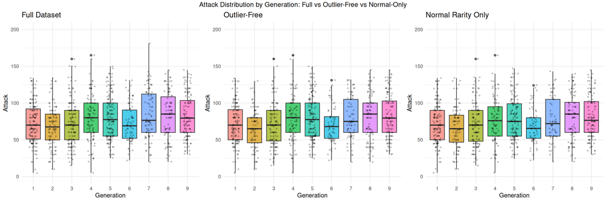

```r
# Plot: Attack distribution by generation (boxplot) - THREE-WAY COMPARISON
p1_full <- ggplot(pokemon, aes(x = gen, y = attack, fill = gen)) +
  geom_boxplot(alpha = 0.7) +
  geom_jitter(width = 0.2, alpha = 0.2, size = 0.8) +
  labs(title = "Full Dataset", x = "Generation", y = "Attack") +
  theme_minimal() +
  theme(legend.position = "none") +
  ylim(0, 200)

p1_clean <- ggplot(pokemon_clean, aes(x = gen, y = attack, fill = gen)) +
  geom_boxplot(alpha = 0.7) +
  geom_jitter(width = 0.2, alpha = 0.2, size = 0.8) +
  labs(title = "Outlier-Free", x = "Generation", y = "Attack") +
  theme_minimal() +
  theme(legend.position = "none") +
  ylim(0, 200)

p1_normal <- ggplot(pokemon_normal, aes(x = gen, y = attack, fill = gen)) +
  geom_boxplot(alpha = 0.7) +
  geom_jitter(width = 0.2, alpha = 0.2, size = 0.8) +
  labs(title = "Normal Rarity Only", x = "Generation", y = "Attack") +
  theme_minimal() +
  theme(legend.position = "none") +
  ylim(0, 200)

gridExtra::grid.arrange(p1_full, p1_clean, p1_normal, ncol = 3,
                        top = "Attack Distribution by Generation: Full vs Outlier-Free vs Normal-Only")
```

**Findings:** Visual inspection shows later generations (4, 5, 7, 8, 9) have higher median attack. The Normal-only plot removes legendary influence — if the pattern persists, power creep affects regular Pokémon too.

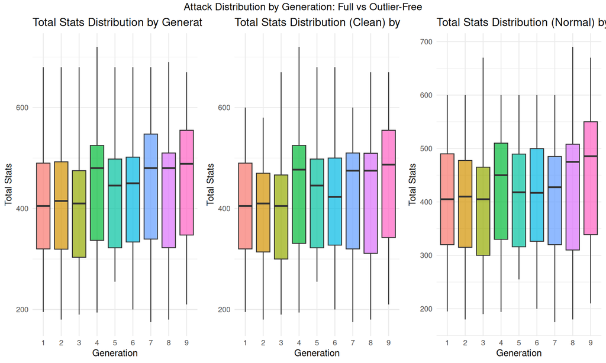

```r
# Plot: Total stats by generation
p2_total <- ggplot(pokemon, aes(x = gen, y = total_stats, fill = gen)) +
  geom_boxplot(alpha = 0.7) +
  labs(title = "Total Stats Distribution by Generation",
       x = "Generation", y = "Total Stats") +
  theme_minimal() +
  theme(legend.position = "none")

p1_clean_total <- ggplot(pokemon_clean, aes(x = gen, y = total_stats, fill = gen)) +
  geom_boxplot(alpha = 0.7) +
  labs(title = "Total Stats Distribution (Clean) by Generation",
       x = "Generation", y = "Total Stats") +
  theme_minimal() +
  theme(legend.position = "none")

p3_normal_total <- ggplot(pokemon_normal, aes(x = gen, y = total_stats, fill = gen)) +
  geom_boxplot(alpha = 0.7) +
  labs(title = "Total Stats Distribution (Normal) by Generation",
       x = "Generation", y = "Total Stats") +
  theme_minimal() +
  theme(legend.position = "none")

gridExtra::grid.arrange( p2_total, p1_clean_total, p3_normal_total,ncol = 3,
                        top = "Attack Distribution by Generation: Full vs Outlier-Free")
```

**Findings:** So far it seems that there is a slight upwards trend in the generations. In all versions. We ca also observe small interesting thing, in the normal dataset we can see that the sum of all the stats seems to have a set celling for stats sum for majority of the generations except 3, 8, 9.

## 3.2 Correlation Matrix

```r
# Correlation matrix for numeric variables
numeric_vars <- pokemon %>%
  dplyr::select(attack, hp, defense, sp_attack, sp_defense, speed,
                height_m, weight_kg, capture_rate, num_abilities, evo_length)

cor_matrix <- cor(numeric_vars, use = "complete.obs")
cat("\nCorrelation matrix (combat stats):\n")
```

```
##
## Correlation matrix (combat stats):
```

```r
print(round(cor_matrix, 2))
```

```
##               attack    hp defense sp_attack sp_defense speed height_m
## attack          1.00  0.48    0.47      0.28       0.23  0.35     0.38
## hp              0.48  1.00    0.30      0.36       0.37  0.18     0.48
## defense         0.47  0.30    1.00      0.21       0.50  0.01     0.35
## sp_attack       0.28  0.36    0.21      1.00       0.49  0.42     0.32
## sp_defense      0.23  0.37    0.50      0.49       1.00  0.21     0.28
## speed           0.35  0.18    0.01      0.42       0.21  1.00     0.20
## height_m        0.38  0.48    0.35      0.32       0.28  0.20     1.00
## weight_kg       0.40  0.48    0.45      0.18       0.26  0.04     0.63
## capture_rate   -0.53 -0.48   -0.46     -0.52      -0.51 -0.41    -0.31
## num_abilities  -0.18 -0.12   -0.17     -0.28      -0.20 -0.19    -0.14
## evo_length     -0.24 -0.22   -0.24     -0.21      -0.27 -0.27    -0.20
##               weight_kg capture_rate num_abilities evo_length
## attack             0.40        -0.53         -0.18      -0.24
## hp                 0.48        -0.48         -0.12      -0.22
## defense            0.45        -0.46         -0.17      -0.24
## sp_attack          0.18        -0.52         -0.28      -0.21
## sp_defense         0.26        -0.51         -0.20      -0.27
## speed              0.04        -0.41         -0.19      -0.27
## height_m           0.63        -0.31         -0.14      -0.20
## weight_kg          1.00        -0.29         -0.20      -0.19
## capture_rate      -0.29         1.00          0.29       0.18
## num_abilities     -0.20         0.29          1.00       0.20
## evo_length        -0.19         0.18          0.20       1.00
```

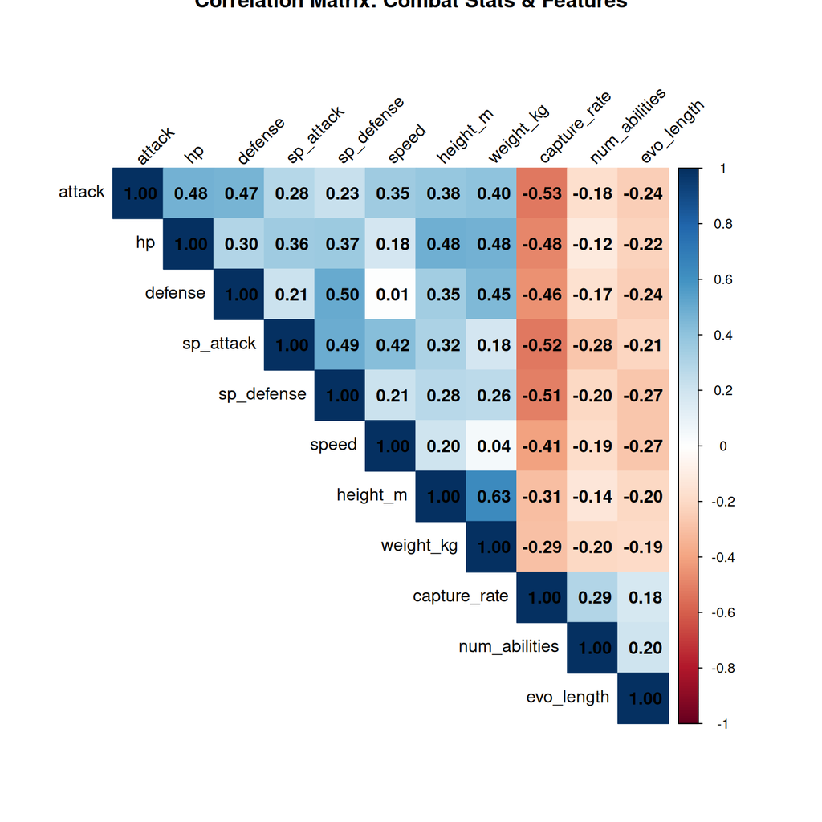

```r
corrplot(cor_matrix, method = "color", type = "upper",
         addCoef.col = "black", tl.col = "black", tl.srt = 45,
         title = "Correlation Matrix: Combat Stats & Features")
```

### 3.2.1 Generation-Specific Correlation Analysis

Do the correlations between combat stats change across generations? If multicollinearity patterns shift, it could indicate changes in Pokémon design philosophy over time.

```r
# Calculate correlation matrices for each generation
combat_vars <- c("attack", "hp", "defense", "sp_attack", "sp_defense", "speed")

# Function to calculate correlation matrix for a generation
calc_gen_cor <- function(data, gen_num) {
  gen_data <- data %>% filter(gen == gen_num) %>% dplyr::select(all_of(combat_vars))
  cor(gen_data, use = "complete.obs")
}

# Calculate correlations for all generations
gen_cors <- lapply(1:9, function(g) calc_gen_cor(pokemon, g))
names(gen_cors) <- paste0("Gen", 1:9)

# Extract key correlations (attack vs other stats) for each generation
attack_cors <- data.frame(
  Generation = 1:9,
  attack_hp = sapply(gen_cors, function(m) m["attack", "hp"]),
  attack_defense = sapply(gen_cors, function(m) m["attack", "defense"]),
  attack_sp_attack = sapply(gen_cors, function(m) m["attack", "sp_attack"]),
  attack_sp_defense = sapply(gen_cors, function(m) m["attack", "sp_defense"]),
  attack_speed = sapply(gen_cors, function(m) m["attack", "speed"])
)

cat("--- Attack Correlations by Generation ---\n")
```

```
## --- Attack Correlations by Generation ---
```

```r
print(round(attack_cors, 3))
```

```
##      Generation attack_hp attack_defense attack_sp_attack attack_sp_defense
## Gen1          1     0.297          0.483            0.140             0.370
## Gen2          2     0.206          0.413            0.392             0.132
## Gen3          3     0.472          0.410            0.545             0.146
## Gen4          4     0.574          0.361            0.389             0.136
## Gen5          5     0.519          0.427            0.176             0.244
## Gen6          6     0.660          0.594            0.428             0.282
## Gen7          7     0.532          0.467            0.273             0.134
## Gen8          8     0.627          0.590            0.203             0.318
## Gen9          9     0.563          0.543            0.040             0.336
##      attack_speed
## Gen1        0.201
## Gen2        0.366
## Gen3        0.359
## Gen4        0.414
## Gen5        0.371
## Gen6        0.221
## Gen7        0.335
## Gen8        0.396
## Gen9        0.411
```

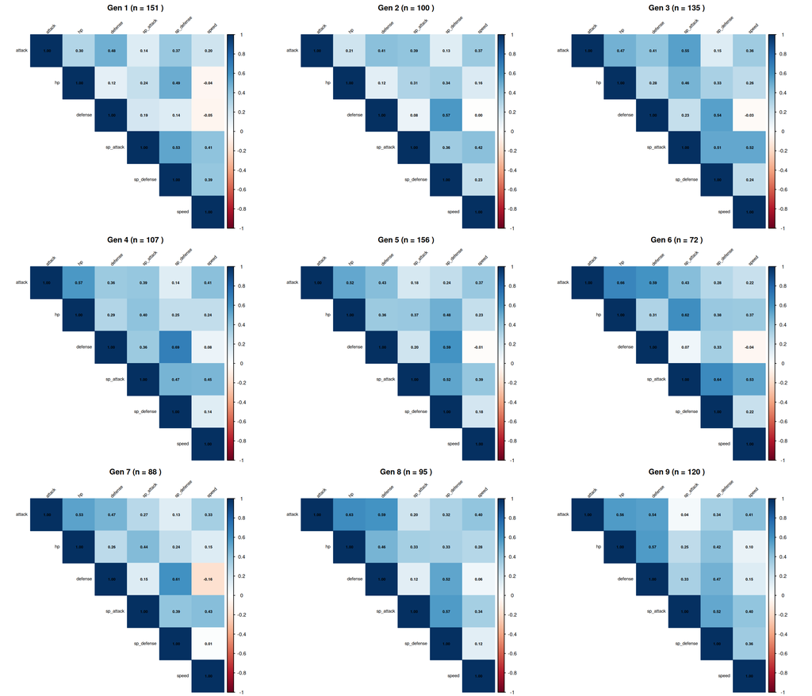

```r
# Visualize correlation matrices by generation (3x3 grid)
par(mfrow = c(3, 3), mar = c(2, 2, 3, 1))
for(g in 1:9) {
  corrplot(gen_cors[[g]], method = "color", type = "upper",
           addCoef.col = "black", tl.col = "black", tl.srt = 45,
           number.cex = 0.6, tl.cex = 0.7,
           title = paste("Gen", g, "(n =", sum(pokemon$gen == g), ")"),
           mar = c(0, 0, 2, 0))
}
```

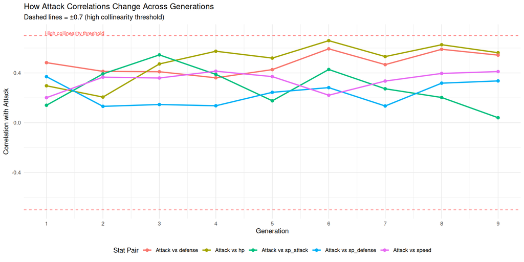

```r
# Plot how attack correlations change over generations
attack_cors_long <- attack_cors %>%
  pivot_longer(cols = -Generation, names_to = "correlation", values_to = "value") %>%
  mutate(correlation = gsub("attack_", "Attack vs ", correlation))

p_cor_trends <- ggplot(attack_cors_long, aes(x = Generation, y = value, color = correlation)) +
  geom_line(linewidth = 1) +
  geom_point(size = 2) +
  geom_hline(yintercept = 0.7, linetype = "dashed", color = "red", alpha = 0.5) +
  geom_hline(yintercept = -0.7, linetype = "dashed", color = "red", alpha = 0.5) +
  annotate("text", x = 1.5, y = 0.72, label = "High collinearity threshold",
           color = "red", size = 3, alpha = 0.7) +
  scale_x_continuous(breaks = 1:9) +
  labs(title = "How Attack Correlations Change Across Generations",
       subtitle = "Dashed lines = ±0.7 (high collinearity threshold)",
       x = "Generation", y = "Correlation with Attack",
       color = "Stat Pair") +
  theme_minimal() +
  theme(legend.position = "bottom")
print(p_cor_trends)
```

```r
# Check for any generation with problematic multicollinearity (|cor| > 0.7)
cat("\n--- Multicollinearity Check by Generation ---\n")
```

```
##
## --- Multicollinearity Check by Generation ---
```

```r
cat("Checking for correlations |r| > 0.7 (high collinearity)\n\n")
```

```
## Checking for correlations |r| > 0.7 (high collinearity)
```

```r
high_cor_summary <- data.frame()
for(g in 1:9) {
  cor_mat <- gen_cors[[g]]
  # Get upper triangle (excluding diagonal)
  cor_mat[lower.tri(cor_mat, diag = TRUE)] <- NA
  high_cors <- which(abs(cor_mat) > 0.7, arr.ind = TRUE)

  if(nrow(high_cors) > 0) {
    for(i in 1:nrow(high_cors)) {
      row_name <- rownames(cor_mat)[high_cors[i, 1]]
      col_name <- colnames(cor_mat)[high_cors[i, 2]]
      cor_val <- cor_mat[high_cors[i, 1], high_cors[i, 2]]
      high_cor_summary <- rbind(high_cor_summary,
                                 data.frame(Generation = g,
                                            Var1 = row_name,
                                            Var2 = col_name,
                                            Correlation = round(cor_val, 3)))
    }
  }
}

if(nrow(high_cor_summary) > 0) {
  cat("Generations with high multicollinearity (|r| > 0.7):\n")
  print(high_cor_summary)
} else {
  cat("No generation has correlations exceeding |r| > 0.7\n")
}
```

```
## No generation has correlations exceeding |r| > 0.7
```

```r
# Summary statistics
cat("\n--- Correlation Stability Summary ---\n")
```

```
##
## --- Correlation Stability Summary ---
```

```r
cor_ranges <- attack_cors %>%
  summarise(
    hp_range = paste0("[", round(min(attack_hp), 2), ", ", round(max(attack_hp), 2), "]"),
    defense_range = paste0("[", round(min(attack_defense), 2), ", ", round(max(attack_defense), 2), "]"),
    sp_attack_range = paste0("[", round(min(attack_sp_attack), 2), ", ", round(max(attack_sp_attack), 2), "]"),
    sp_defense_range = paste0("[", round(min(attack_sp_defense), 2), ", ", round(max(attack_sp_defense), 2), "]"),
    speed_range = paste0("[", round(min(attack_speed), 2), ", ", round(max(attack_speed), 2), "]")
  )
cat("Range of attack correlations across generations:\n")
```

```
## Range of attack correlations across generations:
```

```r
cat("  Attack vs HP:", cor_ranges$hp_range, "\n")
```

```
##   Attack vs HP: [0.21, 0.66]
```

```r
cat("  Attack vs Defense:", cor_ranges$defense_range, "\n")
```

```
##   Attack vs Defense: [0.36, 0.59]
```

```r
cat("  Attack vs Sp.Attack:", cor_ranges$sp_attack_range, "\n")
```

```
##   Attack vs Sp.Attack: [0.04, 0.55]
```

```r
cat("  Attack vs Sp.Defense:", cor_ranges$sp_defense_range, "\n")
```

```
##   Attack vs Sp.Defense: [0.13, 0.37]
```

```r
cat("  Attack vs Speed:", cor_ranges$speed_range, "\n")
```

```
##   Attack vs Speed: [0.2, 0.41]
```

## 3.3 Attack Distribution per Generation

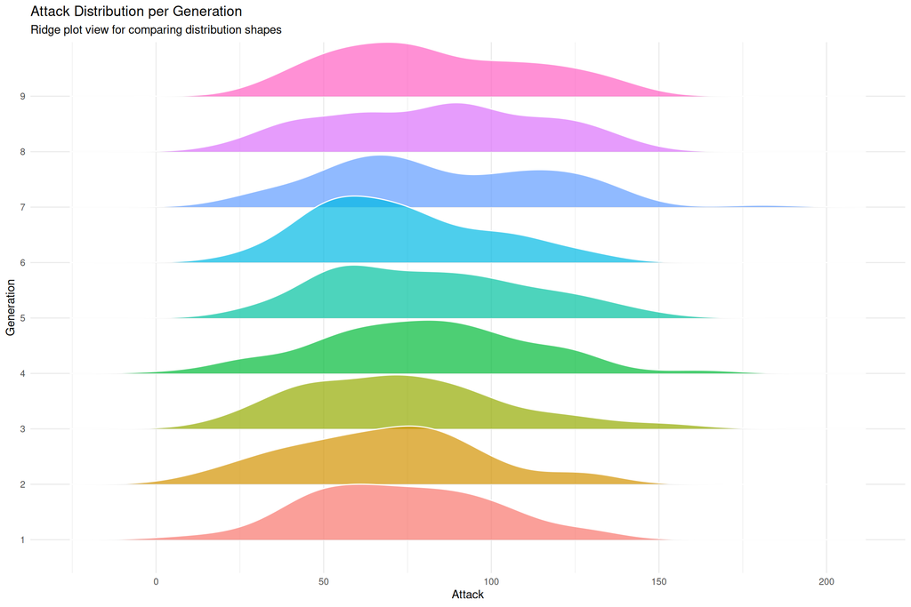

```r
library(ggplot2)
library(ggridges)
library(dplyr)

p_ridge <- pokemon %>%
  ggplot(aes(x = attack, y = as.factor(gen), fill = as.factor(gen))) +
  geom_density_ridges(alpha = 0.7, color = "white", scale = 1.2) +
  labs(
    title = "Attack Distribution per Generation",
    subtitle = "Ridge plot view for comparing distribution shapes",
    x = "Attack",
    y = "Generation",
    fill = "Generation"
  ) +
  theme_minimal() +
  theme(legend.position = "none")

print(p_ridge)
```

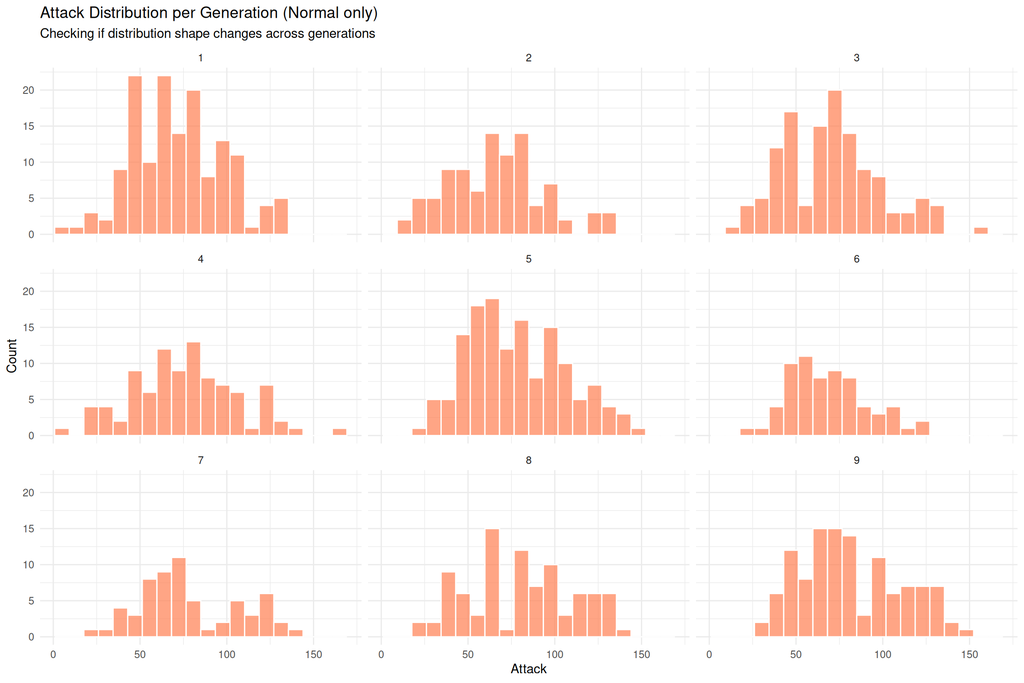

```r
p_dist <- pokemon_normal %>%
  ggplot(aes(x = attack)) +
  geom_histogram(bins = 20, fill = "coral", color = "white", alpha = 0.7) +
  facet_wrap(~gen, ncol = 3) +
  labs(title = "Attack Distribution per Generation (Normal only)",
       subtitle = "Checking if distribution shape changes across generations",
       x = "Attack", y = "Count") +
  theme_minimal()
print(p_dist)
```

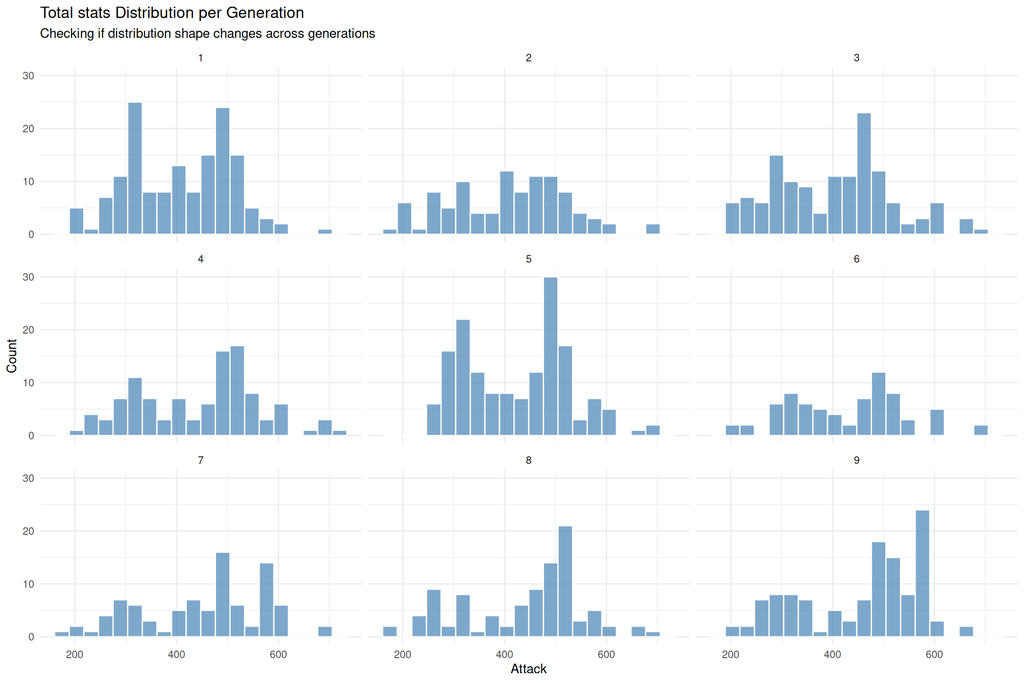

```r
p_dist <- pokemon %>%
  ggplot(aes(x = total_stats)) +
  geom_histogram(bins = 20, fill = "steelblue", color = "white", alpha = 0.7) +
  facet_wrap(~gen, ncol = 3) +
  labs(title = "Total stats Distribution per Generation",
       subtitle = "Checking if distribution shape changes across generations",
       x = "Attack", y = "Count") +
  theme_minimal()
print(p_dist)
```

We can see slight shift in the total stats through generations. It was normal distribution like at the first generation, then it gets more skewed to heavy end tails.

## 3.4 Distribution of All Combat Stats (GLM Prerequisites)

Before applying GLMs, we need to verify that our response variables are approximately normally distributed. This section examines the distribution of all six combat stats.

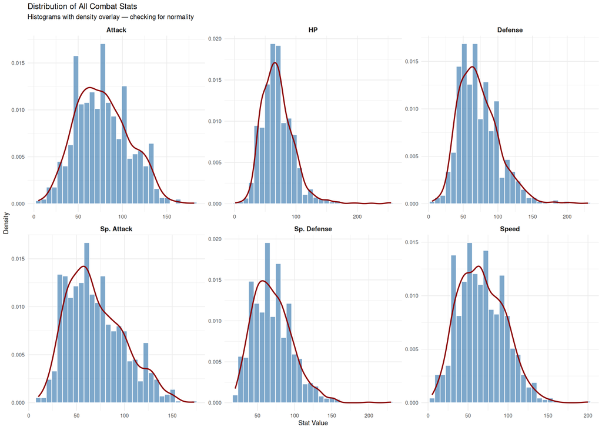

```r
# Reshape data to long format for faceted plotting
combat_stats_long <- pokemon %>%
  dplyr::select(attack, hp, defense, sp_attack, sp_defense, speed) %>%
  pivot_longer(cols = everything(), names_to = "stat", values_to = "value") %>%
  mutate(stat = factor(stat,
                       levels = c("attack", "hp", "defense", "sp_attack", "sp_defense", "speed"),
                       labels = c("Attack", "HP", "Defense", "Sp. Attack", "Sp. Defense", "Speed")))

# Plot distributions with density overlay
p_all_stats <- ggplot(combat_stats_long, aes(x = value)) +
  geom_histogram(aes(y = after_stat(density)), bins = 30,
                 fill = "steelblue", color = "white", alpha = 0.7) +
  geom_density(color = "darkred", linewidth = 1) +
  facet_wrap(~ stat, scales = "free", ncol = 3) +
  labs(title = "Distribution of All Combat Stats",
       subtitle = "Histograms with density overlay — checking for normality",
       x = "Stat Value", y = "Density") +
  theme_minimal() +
  theme(strip.text = element_text(face = "bold", size = 11))
print(p_all_stats)
```

```r
# Comprehensive summary statistics for all combat stats
stats_summary <- pokemon %>%
  dplyr::select(attack, hp, defense, sp_attack, sp_defense, speed, total_stats) %>%
  pivot_longer(cols = everything(), names_to = "stat", values_to = "value") %>%
  group_by(stat) %>%
  summarise(
    n = n(),
    mean = round(mean(value), 1),
    median = round(median(value), 1),
    sd = round(sd(value), 1),
    min = min(value),
    max = max(value),
    skewness = round(moments::skewness(value), 2),
    kurtosis = round(moments::kurtosis(value), 2),
    .groups = "drop"
  ) %>%
  mutate(stat = factor(stat,
                       levels = c("attack", "hp", "defense", "sp_attack", "sp_defense", "speed", "total_stats"),
                       labels = c("Attack", "HP", "Defense", "Sp.Attack", "Sp.Defense", "Speed", "Total Stats"))) %>%
  arrange(stat)

cat("--- Summary Statistics for All Combat Stats ---\n")
```

```
## --- Summary Statistics for All Combat Stats ---
```

```r
print(stats_summary)
```

```
## # A tibble: 7 × 9
##   stat            n  mean median    sd   min   max skewness kurtosis
##   <fct>       <int> <dbl>  <dbl> <dbl> <dbl> <dbl>    <dbl>    <dbl>
## 1 Attack       1024  77.5   75    29.8     5   181     0.28     2.56
## 2 HP           1024  70.2   68    26.6     1   255     1.51     9.08
## 3 Defense      1024  72.5   70    29.3     5   230     0.96     4.86
## 4 Sp.Attack    1024  70     65    29.7    10   173     0.58     2.76
## 5 Sp.Defense   1024  70.2   66.5  26.7    20   230     0.82     4.53
## 6 Speed        1024  67.2   65    28.7     5   200     0.39     2.93
## 7 Total Stats  1024 428.   450   113.    175   720    -0.09     2.2
```

```r
# Interpretation
cat("\n--- Normality Assessment ---\n")
```

```
##
## --- Normality Assessment ---
```

```r
cat("Skewness interpretation: |skew| < 0.5 = approximately symmetric\n")
```

```
## Skewness interpretation: |skew| < 0.5 = approximately symmetric
```

```r
cat("                         |skew| 0.5-1 = moderately skewed\n")
```

```
##                          |skew| 0.5-1 = moderately skewed
```

```r
cat("                         |skew| > 1   = highly skewed\n\n")
```

```
##                          |skew| > 1   = highly skewed
```

```r
for(i in 1:nrow(stats_summary)) {
  skew <- abs(stats_summary$skewness[i])
  assessment <- ifelse(skew < 0.5, "approximately symmetric",
                       ifelse(skew < 1, "moderately skewed", "highly skewed"))
  cat(paste0(stats_summary$stat[i], ": skewness = ", stats_summary$skewness[i],
             " (", assessment, ")\n"))
}
```

```
## Attack: skewness = 0.28 (approximately symmetric)
## HP: skewness = 1.51 (highly skewed)
## Defense: skewness = 0.96 (moderately skewed)
## Sp.Attack: skewness = 0.58 (moderately skewed)
## Sp.Defense: skewness = 0.82 (moderately skewed)
## Speed: skewness = 0.39 (approximately symmetric)
## Total Stats: skewness = -0.09 (approximately symmetric)
```

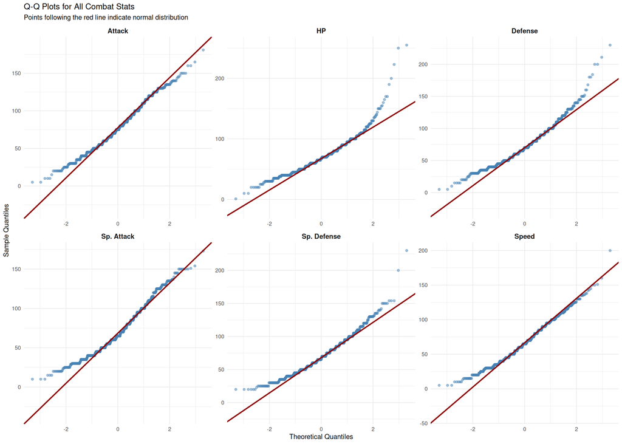

```r
# Q-Q plots to assess normality
p_qq <- ggplot(combat_stats_long, aes(sample = value)) +
  stat_qq(color = "steelblue", alpha = 0.5) +
  stat_qq_line(color = "darkred", linewidth = 1) +
  facet_wrap(~ stat, scales = "free", ncol = 3) +
  labs(title = "Q-Q Plots for All Combat Stats",
       subtitle = "Points following the red line indicate normal distribution",
       x = "Theoretical Quantiles", y = "Sample Quantiles") +
  theme_minimal() +
  theme(strip.text = element_text(face = "bold", size = 11))
print(p_qq)
```

```r
# Formal normality tests (Shapiro-Wilk)
# Note: With large samples, even small deviations become significant
cat("\n--- Shapiro-Wilk Normality Tests ---\n")
```

```
##
## --- Shapiro-Wilk Normality Tests ---
```

```r
cat("Note: With n = 1024, even minor deviations from normality become detectable.\n")
```

```
## Note: With n = 1024, even minor deviations from normality become detectable.
```

```r
cat("      Focus on visual assessment (Q-Q plots) for practical evaluation.\n\n")
```

```
##       Focus on visual assessment (Q-Q plots) for practical evaluation.
```

```r
# Test each stat (use sample of 5000 max due to Shapiro-Wilk limit)
set.seed(42)
for(stat_name in c("attack", "hp", "defense", "sp_attack", "sp_defense", "speed")) {
  values <- pokemon[[stat_name]]
  if(length(values) > 5000) values <- sample(values, 5000)
  test_result <- shapiro.test(values)
  cat(paste0(stat_name, ": W = ", round(test_result$statistic, 4),
             ", p = ", format(test_result$p.value, digits = 3), "\n"))
}
```

```
## attack: W = 0.9874, p = 1.02e-07
## hp: W = 0.9176, p = 3.58e-23
## defense: W = 0.9533, p = 1.59e-17
## sp_attack: W = 0.9658, p = 8.92e-15
## sp_defense: W = 0.9629, p = 1.79e-15
## speed: W = 0.9842, p = 4.25e-09
```

**Findings for GLM Prerequisites:**

This supports using **Gaussian GLM with identity link** as our primary specification. The slight right skewness justifies using **Gamma GLM** as a robustness check.

## 3.5 Variance Analysis Across Generations (Homoscedasticity Check)

For Gaussian GLMs, we assume constant variance (homoscedasticity). We need to verify that the variance of each combat stat does not systematically change across generations.

```r
# Calculate mean and SD for each stat by generation
variance_summary <- pokemon %>%
  group_by(gen) %>%
  summarise(
    n = n(),
    attack_mean = mean(attack), attack_sd = sd(attack),
    hp_mean = mean(hp), hp_sd = sd(hp),
    defense_mean = mean(defense), defense_sd = sd(defense),
    sp_attack_mean = mean(sp_attack), sp_attack_sd = sd(sp_attack),
    sp_defense_mean = mean(sp_defense), sp_defense_sd = sd(sp_defense),
    speed_mean = mean(speed), speed_sd = sd(speed),
    .groups = "drop"
  )

cat("--- Standard Deviations by Generation (All Combat Stats) ---\n\n")
```

```
## --- Standard Deviations by Generation (All Combat Stats) ---
```

```r
sd_table <- variance_summary %>%
  dplyr::select(gen, n, attack_sd, hp_sd, defense_sd, sp_attack_sd, sp_defense_sd, speed_sd) %>%
  mutate(across(ends_with("_sd"), ~ round(.x, 1)))
print(sd_table)
```

```
## # A tibble: 9 × 8
##   gen       n attack_sd hp_sd defense_sd sp_attack_sd sp_defense_sd speed_sd
##   <fct> <int>     <dbl> <dbl>      <dbl>        <dbl>         <dbl>    <dbl>
## 1 1       151      26.8  28.6       26.9         28.5          24.2     27
## 2 2       100      28.4  31.2       35.2         25.6          31.5     27.2
## 3 3       135      30.4  25.2       31.1         28.3          28.5     26.9
## 4 4       107      30.9  24.7       30.7         31.2          27.8     27.6
## 5 5       156      29.4  21.6       23           29.8          21.9     28.2
## 6 6        72      25.6  21.7       31.3         28            30.4     25.9
## 7 7        88      32.9  28.1       32.9         33.8          28.6     30.9
## 8 8        95      31.3  27.4       27           29.4          24.1     34.1
## 9 9       120      29.3  28.2       27.8         31.5          24.6     29.4
```

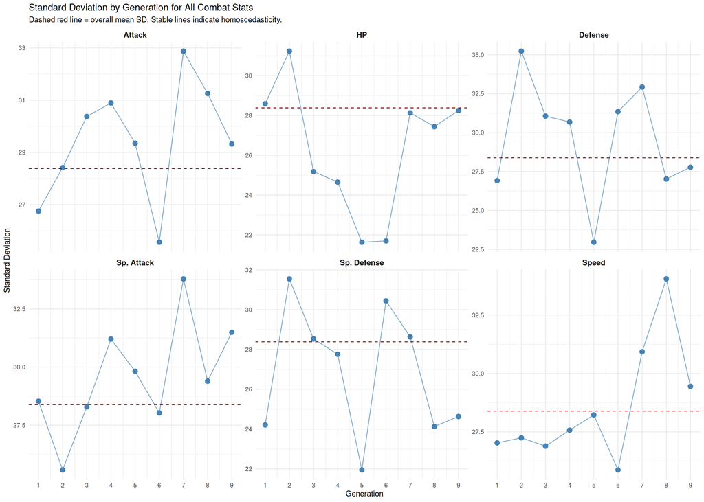

```r
# Reshape for plotting
variance_long <- variance_summary %>%
  dplyr::select(gen, ends_with("_sd")) %>%
  pivot_longer(cols = -gen, names_to = "stat", values_to = "sd") %>%
  mutate(stat = gsub("_sd", "", stat),
         stat = factor(stat,
                       levels = c("attack", "hp", "defense", "sp_attack", "sp_defense", "speed"),
                       labels = c("Attack", "HP", "Defense", "Sp. Attack", "Sp. Defense", "Speed")))

# Plot SD by generation for each stat
p_variance <- ggplot(variance_long, aes(x = as.numeric(as.character(gen)), y = sd)) +
  geom_point(size = 3, color = "steelblue") +
  geom_line(color = "steelblue", alpha = 0.7) +
  geom_hline(aes(yintercept = mean(sd)), linetype = "dashed", color = "darkred") +
  facet_wrap(~ stat, scales = "free_y", ncol = 3) +
  scale_x_continuous(breaks = 1:9) +
  labs(title = "Standard Deviation by Generation for All Combat Stats",
       subtitle = "Dashed red line = overall mean SD. Stable lines indicate homoscedasticity.",
       x = "Generation", y = "Standard Deviation") +
  theme_minimal() +
  theme(strip.text = element_text(face = "bold", size = 11))
print(p_variance)
```

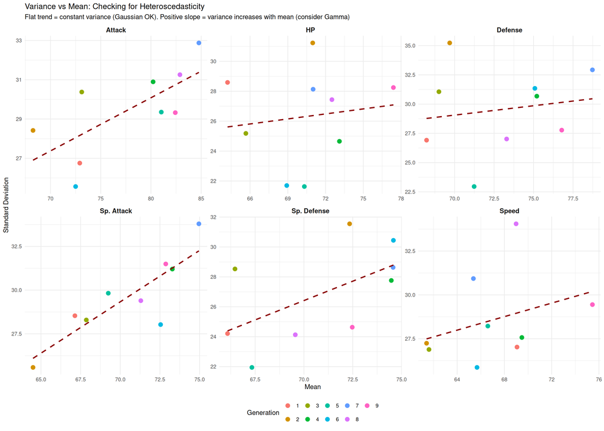

```r
# Plot SD vs Mean to check if variance increases with mean
mean_long <- variance_summary %>%
  dplyr::select(gen, ends_with("_mean")) %>%
  pivot_longer(cols = -gen, names_to = "stat", values_to = "mean") %>%
  mutate(stat = gsub("_mean", "", stat))

variance_vs_mean <- variance_long %>%
  mutate(stat_raw = tolower(gsub(" ", "_", gsub("\\. ", "_", stat)))) %>%
  left_join(mean_long %>% rename(stat_raw = stat), by = c("gen", "stat_raw"))

p_var_vs_mean <- ggplot(variance_vs_mean, aes(x = mean, y = sd)) +
  geom_point(aes(color = factor(gen)), size = 3) +
  geom_smooth(method = "lm", se = FALSE, color = "darkred", linetype = "dashed") +
  facet_wrap(~ stat, scales = "free", ncol = 3) +
  labs(title = "Variance vs Mean: Checking for Heteroscedasticity",
       subtitle = "Flat trend = constant variance (Gaussian OK). Positive slope = variance increases with mean (consider Gamma)",
       x = "Mean", y = "Standard Deviation", color = "Generation") +
  theme_minimal() +
  theme(strip.text = element_text(face = "bold", size = 11),
        legend.position = "bottom")
print(p_var_vs_mean)
```

```r
# For simple model (attack ~ gen), gen is a factor so fitted values are discrete
# Standard residual plots show vertical lines - not useful for visual inspection
# Instead, we examine residual distribution BY GENERATION using boxplots

model_simple <- lm(attack ~ gen, data = pokemon)

cat("--- Simple Model: Attack ~ Generation ---\n")
```

```
## --- Simple Model: Attack ~ Generation ---
```

```r
cat("Note: Since generation is a categorical factor, we use boxplots\n")
```

```
## Note: Since generation is a categorical factor, we use boxplots
```

```r
cat("      to visualize residual spread within each generation.\n\n")
```

```
##       to visualize residual spread within each generation.
```

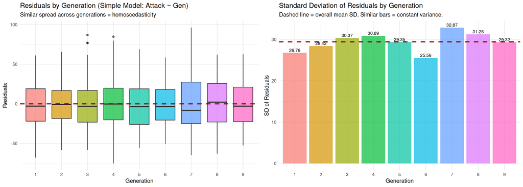

```r
# Add residuals to data
pokemon_resid <- pokemon %>%
  mutate(residuals = residuals(model_simple),
         fitted = fitted(model_simple))

# Boxplot of residuals by generation (better for factor predictor)
p_resid_box <- ggplot(pokemon_resid, aes(x = gen, y = residuals, fill = gen)) +
  geom_boxplot(alpha = 0.7) +
  geom_hline(yintercept = 0, color = "darkred", linetype = "dashed", linewidth = 1) +
  labs(title = "Residuals by Generation (Simple Model: Attack ~ Gen)",
       subtitle = "Similar spread across generations = homoscedasticity",
       x = "Generation", y = "Residuals") +
  theme_minimal() +
  theme(legend.position = "none")

# SD of residuals by generation
resid_sd <- pokemon_resid %>%
  group_by(gen) %>%
  summarise(n = n(), sd_residuals = round(sd(residuals), 2), .groups = "drop")

p_resid_sd <- ggplot(resid_sd, aes(x = gen, y = sd_residuals, fill = gen)) +
  geom_col(alpha = 0.7) +
  geom_hline(yintercept = mean(resid_sd$sd_residuals), color = "darkred",
             linetype = "dashed", linewidth = 1) +
  geom_text(aes(label = sd_residuals), vjust = -0.3, size = 3) +
  labs(title = "Standard Deviation of Residuals by Generation",
       subtitle = "Dashed line = overall mean SD. Similar bars = constant variance.",
       x = "Generation", y = "SD of Residuals") +
  theme_minimal() +
  theme(legend.position = "none")

gridExtra::grid.arrange(p_resid_box, p_resid_sd, ncol = 2)
```

```r
cat("Residual SD by generation:\n")
```

```
## Residual SD by generation:
```

```r
print(resid_sd)
```

```
## # A tibble: 9 × 3
##   gen       n sd_residuals
##   <fct> <int>        <dbl>
## 1 1       151         26.8
## 2 2       100         28.4
## 3 3       135         30.4
## 4 4       107         30.9
## 5 5       156         29.4
## 6 6        72         25.6
## 7 7        88         32.9
## 8 8        95         31.3
## 9 9       120         29.3
```

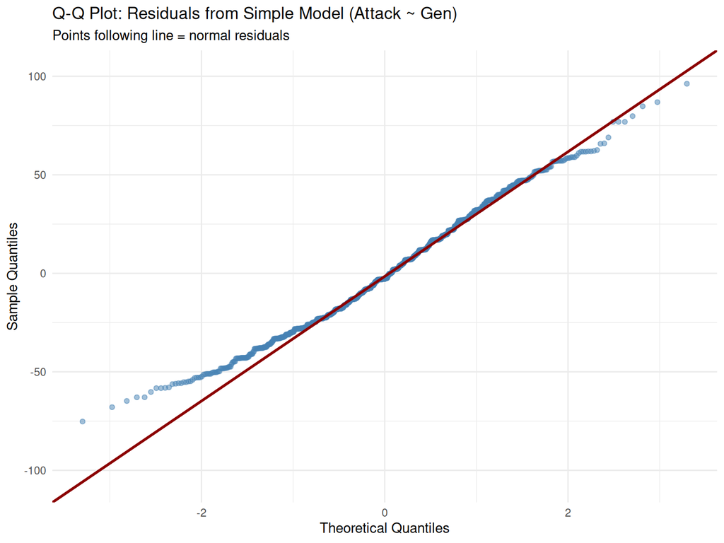

```r
# Q-Q plot for normality of residuals (simple model)
p_qq_simple <- ggplot(pokemon_resid, aes(sample = residuals)) +
  stat_qq(color = "steelblue", alpha = 0.5) +
  stat_qq_line(color = "darkred", linewidth = 1) +
  labs(title = "Q-Q Plot: Residuals from Simple Model (Attack ~ Gen)",
       subtitle = "Points following line = normal residuals",
       x = "Theoretical Quantiles", y = "Sample Quantiles") +
  theme_minimal()
print(p_qq_simple)
```

```r
# Breusch-Pagan tests on SIMPLE models (stat ~ gen only)
cat("\n--- Breusch-Pagan Tests: SIMPLE Models (stat ~ gen) ---\n")
```

```
##
## --- Breusch-Pagan Tests: SIMPLE Models (stat ~ gen) ---
```

```r
cat("H₀: Constant variance (homoscedasticity)\n")
```

```
## H₀: Constant variance (homoscedasticity)
```

```r
cat("H₁: Variance changes with fitted values (heteroscedasticity)\n\n")
```

```
## H₁: Variance changes with fitted values (heteroscedasticity)
```

```r
bp_simple <- data.frame(
  Stat = character(),
  BP_statistic = numeric(),
  df = numeric(),
  p_value = numeric(),
  Conclusion = character(),
  stringsAsFactors = FALSE
)

for(stat_name in c("attack", "hp", "defense", "sp_attack", "sp_defense", "speed")) {
  formula_str <- as.formula(paste(stat_name, "~ gen"))
  model <- lm(formula_str, data = pokemon)
  bp_test <- bptest(model)

  conclusion <- ifelse(bp_test$p.value < 0.05,
                       "Heteroscedastic", "Homoscedastic")

  bp_simple <- rbind(bp_simple, data.frame(
    Stat = stat_name,
    BP_statistic = round(bp_test$statistic, 3),
    df = bp_test$parameter,
    p_value = round(bp_test$p.value, 4),
    Conclusion = conclusion
  ))
}

print(bp_simple)
```

```
##           Stat BP_statistic df p_value      Conclusion
## BP      attack       11.553  8  0.1723   Homoscedastic
## BP1         hp        6.082  8  0.6381   Homoscedastic
## BP2    defense       15.240  8  0.0546   Homoscedastic
## BP3  sp_attack       12.080  8  0.1477   Homoscedastic
## BP4 sp_defense       15.663  8  0.0475 Heteroscedastic
## BP5      speed       13.693  8  0.0901   Homoscedastic
```

```r
# Now test on FULL model with all controls (more realistic)
# With continuous predictors (hp, defense, speed, etc.), fitted values have proper spread
# so standard diagnostic plots are now meaningful

cat("\n--- Standard Diagnostic Plots: FULL Model ---\n")
```

```
##
## --- Standard Diagnostic Plots: FULL Model ---
```

```r
cat("Model: attack ~ gen + hp + defense + sp_attack + sp_defense + speed + rarity\n")
```

```
## Model: attack ~ gen + hp + defense + sp_attack + sp_defense + speed + rarity
```

```r
cat("With continuous controls, fitted values have proper spread for diagnostics.\n\n")
```

```
## With continuous controls, fitted values have proper spread for diagnostics.
```

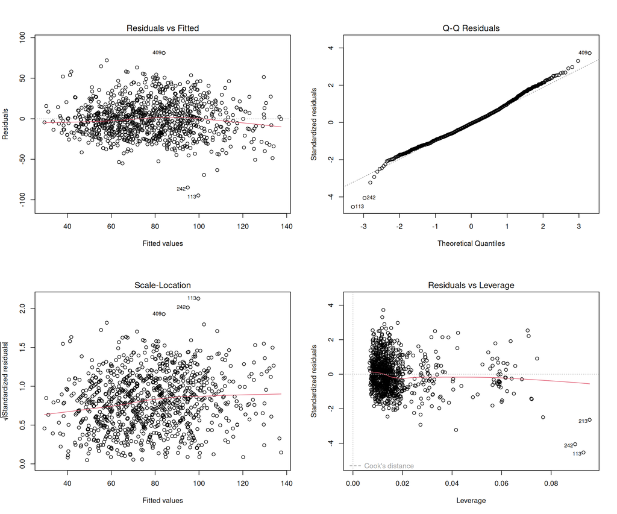

```r
model_full_diag <- lm(attack ~ gen + hp + defense + sp_attack + sp_defense + speed + rarity,
                      data = pokemon)

par(mfrow = c(2, 2))
plot(model_full_diag)
```

```r
# Summary of model
cat("\n--- Full Model R-squared ---\n")
```

```
##
## --- Full Model R-squared ---
```

```r
cat("R² =", round(summary(model_full_diag)$r.squared, 4), "\n")
```

```
## R² = 0.4674
```

```r
cat("Adjusted R² =", round(summary(model_full_diag)$adj.r.squared, 4), "\n")
```

```
## Adjusted R² = 0.459
```

```r
# Breusch-Pagan tests on FULL models (stat ~ gen + controls)
cat("\n--- Breusch-Pagan Tests: FULL Models (with controls) ---\n")
```

```
##
## --- Breusch-Pagan Tests: FULL Models (with controls) ---
```

```r
cat("This is more relevant since we will use full models in our analysis.\n\n")
```

```
## This is more relevant since we will use full models in our analysis.
```

```r
bp_full <- data.frame(
  Stat = character(),
  Model = character(),
  BP_statistic = numeric(),
  df = numeric(),
  p_value = numeric(),
  Conclusion = character(),
  stringsAsFactors = FALSE
)

# Define control variables (excluding the target stat itself)
for(stat_name in c("attack", "hp", "defense", "sp_attack", "sp_defense", "speed")) {
  # Get other stats as controls
  other_stats <- setdiff(c("hp", "defense", "sp_attack", "sp_defense", "speed"), stat_name)
  controls <- paste(c("gen", other_stats, "rarity"), collapse = " + ")

  formula_str <- as.formula(paste(stat_name, "~", controls))
  model <- lm(formula_str, data = pokemon)
  bp_test <- bptest(model)

  conclusion <- ifelse(bp_test$p.value < 0.05,
                       "Heteroscedastic", "Homoscedastic")

  bp_full <- rbind(bp_full, data.frame(
    Stat = stat_name,
    Model = "Full",
    BP_statistic = round(bp_test$statistic, 3),
    df = bp_test$parameter,
    p_value = round(bp_test$p.value, 4),
    Conclusion = conclusion
  ))
}

print(bp_full)
```

```
##           Stat Model BP_statistic df p_value      Conclusion
## BP      attack  Full       89.871 16  0.0000 Heteroscedastic
## BP1         hp  Full       49.001 15  0.0000 Heteroscedastic
## BP2    defense  Full       74.643 15  0.0000 Heteroscedastic
## BP3  sp_attack  Full       84.799 15  0.0000 Heteroscedastic
## BP4 sp_defense  Full      114.917 15  0.0000 Heteroscedastic
## BP5      speed  Full       30.161 15  0.0114 Heteroscedastic
```

```r
# Summary comparison
cat("\n--- Summary: Simple vs Full Model Heteroscedasticity ---\n")
```

```
##
## --- Summary: Simple vs Full Model Heteroscedasticity ---
```

```r
comparison <- data.frame(
  Stat = bp_simple$Stat,
  Simple_p = bp_simple$p_value,
  Full_p = bp_full$p_value,
  Simple_Result = bp_simple$Conclusion,
  Full_Result = bp_full$Conclusion
)
print(comparison)
```

```
##         Stat Simple_p Full_p   Simple_Result     Full_Result
## 1     attack   0.1723 0.0000   Homoscedastic Heteroscedastic
## 2         hp   0.6381 0.0000   Homoscedastic Heteroscedastic
## 3    defense   0.0546 0.0000   Homoscedastic Heteroscedastic
## 4  sp_attack   0.1477 0.0000   Homoscedastic Heteroscedastic
## 5 sp_defense   0.0475 0.0000 Heteroscedastic Heteroscedastic
## 6      speed   0.0901 0.0114   Homoscedastic Heteroscedastic
```

```r
cat("\nSimple models homoscedastic:", sum(bp_simple$p_value >= 0.05), "out of 6\n")
```

```
##
## Simple models homoscedastic: 5 out of 6
```